# Quiz 2 Mineria de Datos

David Moreno

2024-02-29

### Universidad de los Andes Minería de Datos – MIIA 4200

Profesor: Rafael Amaya Gómez

## Punto 1

El dataset Wage (librería ISLR) trabajado en clase tiene otras variables no exploradas como el estado marital (maritl), o la clase de trabajo (jobclass) y otras. Explore las relaciones entre por lo menos estas dos variables con la variable respecto a wage, usando técnicas de ajuste no lineal para ajustar modelos flexibles a los datos. Cree figuras de los resultados obtenidos y describa un resumen de sus hallazgos.

```r
library(tidyverse)
```

```r
library(ggplot2)
library(tidyr)
library(mgcv)
load("auto.Rdata")
load("wage.Rdata")

head(Wage)
```

```
##        year age           maritl     race       education             region
## 231655 2006  18 1. Never Married 1. White    1. < HS Grad 2. Middle Atlantic
## 86582  2004  24 1. Never Married 1. White 4. College Grad 2. Middle Atlantic
## 161300 2003  45       2. Married 1. White 3. Some College 2. Middle Atlantic
## 155159 2003  43       2. Married 3. Asian 4. College Grad 2. Middle Atlantic
## 11443  2005  50      4. Divorced 1. White      2. HS Grad 2. Middle Atlantic
## 376662 2008  54       2. Married 1. White 4. College Grad 2. Middle Atlantic
##              jobclass         health health_ins  logwage      wage
## 231655  1. Industrial      1. <=Good      2. No 4.318063  75.04315
## 86582  2. Information 2. >=Very Good      2. No 4.255273  70.47602
## 161300  1. Industrial      1. <=Good     1. Yes 4.875061 130.98218
## 155159 2. Information 2. >=Very Good     1. Yes 5.041393 154.68529
## 11443  2. Information      1. <=Good     1. Yes 4.318063  75.04315
## 376662 2. Information 2. >=Very Good     1. Yes 4.845098 127.11574
```

Prmiero vemos de qué tipo son nuestras variables

```r
str(Wage)
```

```
## 'data.frame':    3000 obs. of  11 variables:
##  $ year      : int  2006 2004 2003 2003 2005 2008 2009 2008 2006 2004 ...
##  $ age       : int  18 24 45 43 50 54 44 30 41 52 ...
##  $ maritl    : Factor w/ 5 levels "1. Never Married",..: 1 1 2 2 4 2 2 1 1 2 ...
##  $ race      : Factor w/ 4 levels "1. White","2. Black",..: 1 1 1 3 1 1 4 3 2 1 ...
##  $ education : Factor w/ 5 levels "1. < HS Grad",..: 1 4 3 4 2 4 3 3 3 2 ...
##  $ region    : Factor w/ 9 levels "1. New England",..: 2 2 2 2 2 2 2 2 2 2 ...
##  $ jobclass  : Factor w/ 2 levels "1. Industrial",..: 1 2 1 2 2 2 1 2 2 2 ...
##  $ health    : Factor w/ 2 levels "1. <=Good","2. >=Very Good": 1 2 1 2 1 2 2 1 2 2 ...
##  $ health_ins: Factor w/ 2 levels "1. Yes","2. No": 2 2 1 1 1 1 1 1 1 1 ...
##  $ logwage   : num  4.32 4.26 4.88 5.04 4.32 ...
##  $ wage      : num  75 70.5 131 154.7 75 ...
```

Vemos que el año es un entero, el dataframe tiene 3000 observaciones con 11 variables para el caso del quiz nos conviene ver las dos variables que estamos considerando que son jobclass y maritl, vemos que la variable jobclass es un factor que tienee 2 niveles y que maritl tiene 5 niveles.

Por lo tanto una buena forma de comenzar el análisis es hacer una gráfica por cada categoria en un box plot mostrando la variable wage

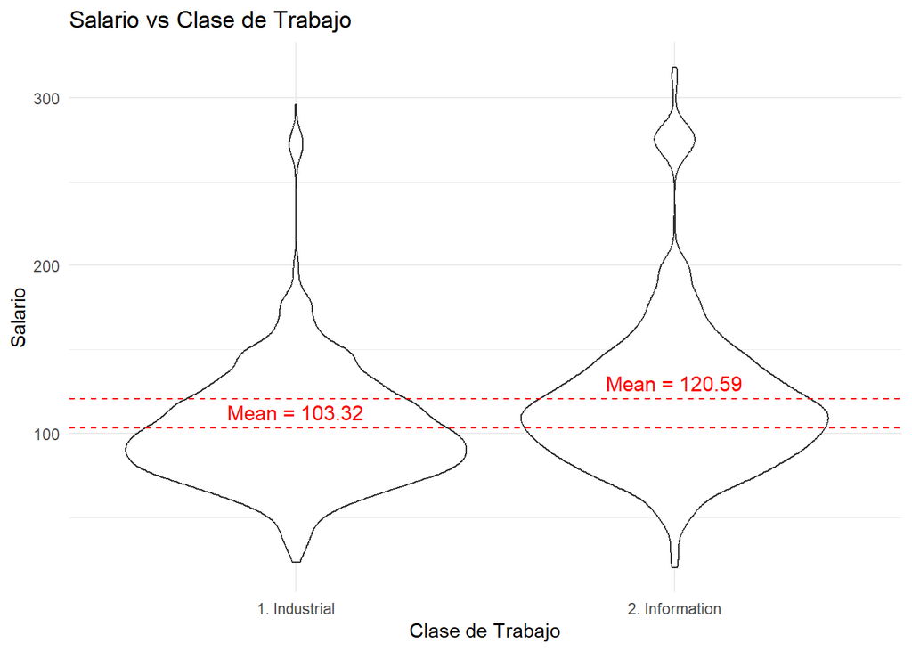

```r
# Calcular el salario promedio por clase de trabajo
mean_wage <- Wage %>%
  group_by(jobclass) %>%
  summarise(mean_wage = mean(wage, na.rm = TRUE))

# Graficar con el salario promedio
ggplot(Wage, aes(x = jobclass, y = wage)) +
  geom_violin() +  # Agregar gráfico de violín
  geom_hline(data = mean_wage, aes(yintercept = mean_wage), color = "red", linetype = "dashed") +  # Línea horizontal para el salario promedio
  geom_text(data = mean_wage, aes(x = jobclass, y = mean_wage, label = paste("Mean =", round(mean_wage, 2))),
            vjust = -0.5, color = "red", size = 4) +  # Texto para mostrar el salario promedio
  labs(title = "Salario vs Clase de Trabajo", x = "Clase de Trabajo", y = "Salario") +  # Etiquetas de título y ejes
  theme_minimal()  # Estilo del gráfico
```

Al analizar el gráfico, se destaca un patrón interesante. En primer lugar, al observar las formas tipo violín, se nota que las personas en el área de información tienden a tener salarios más altos, con una media alrededor de 120, mientras que en el área industrial la media está aproximadamente en 103. Además, llama la atención la presencia de algunos valores atípicos en ambas columnas, especialmente más prominentes en el área de información, lo que sugiere que, en general, aquellos en el campo de la información obtienen salarios más altos. Además, parece que estos casos de salarios excepcionalmente altos son más frecuentes en el área de información que en la industrial.

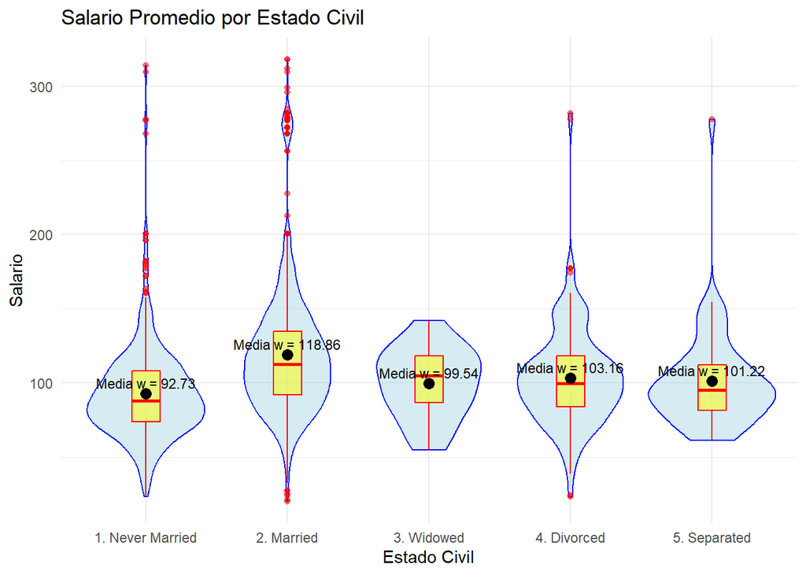

```r
# Calcular el salario promedio por estado civil
mean_wage_marital <- Wage %>%
  group_by(maritl) %>%
  summarise(mean_wage = mean(wage, na.rm = TRUE))

# Graficar el salario promedio por estado civil con violin plot y boxplot
ggplot(Wage, aes(x = maritl, y = wage)) +
  geom_violin(color = "blue", fill = "lightblue", alpha = 0.5) +  # Agregar gráfico de violín
  geom_boxplot(width = 0.2, color = "red", fill = "yellow", alpha = 0.5) +  # Agregar gráfico de boxplot
  geom_point(data = mean_wage_marital, aes(y = mean_wage), color = "black", size = 3) +  # Puntos para mostrar el salario promedio
  geom_text(data = mean_wage_marital, aes(y = mean_wage, label = paste("Media w =", round(mean_wage, 2))),
            vjust = -0.5, color = "black", size = 3) +  # Texto para mostrar el salario promedio
  labs(title = "Salario Promedio por Estado Civil", x = "Estado Civil", y = "Salario") +  # Etiquetas de título y ejes
  theme_minimal()  # Estilo del gráfico
```

Observamos que la media de los individuos que nunca se han casado es la más baja en comparación con los demás estados civiles. Sin embargo, observamos valores atípicos en los salarios más altos. Para las personas casadas, vemos que la media es la más alta con 118, y que existe una alta tendencia a tener valores atípicos más pronunciados en los salarios altos. Para las personas viudas, vemos que no hay valores atípicos y en general los datos están bastante centrados en la media. Para las personas divorciadas, vemos que tienen una media de alrededor de 104 con algunos valores altos pero menos pronunciados que en los grupos de personas nunca casadas y casadas

### Regresion Lineal

```r
# Seleccionar las columnas relevantes de Wage y asignarlas a Wage_regression
Wage_regression <- Wage %>%
  select(jobclass, wage, age, maritl)

# Realizar one-hot encoding para la variable 'maritl'
one_hot_maritl <- model.matrix(~ 0 + maritl, data = Wage)
# Realizar one-hot encoding para la variable 'jobclass'
one_hot_jobclass <- model.matrix(~ 0 + jobclass, data = Wage)

# Combinar las variables codificadas con Wage_regression
Wage_regression <- cbind(Wage_regression, one_hot_maritl, one_hot_jobclass)

# Renombrar las columnas según su posición en el conjunto de datos
colnames(Wage_regression) <- c("jobclass", "wage", "age", "maritl", "Never_Married",
                               "Married", "Widowed", "Divorced", "Separated",
                               "Industrial", "Information")

# Realizar la regresión lineal con las variables seleccionadas
regression_model <- lm(wage ~ age + Never_Married + Married + Widowed +
                       Divorced + Separated + Industrial + Information,
                       data = Wage_regression)

# Mostrar el resumen de la regresión
summary(regression_model)
```

```
##
## Call:
## lm(formula = wage ~ age + Never_Married + Married + Widowed +
##     Divorced + Separated + Industrial + Information, data = Wage_regression)
##
## Residuals:
##      Min       1Q   Median       3Q      Max
## -107.882  -23.441   -5.329   15.976  210.850
##
## Coefficients: (2 not defined because of singularities)
##                Estimate Std. Error t value Pr(>|t|)
## (Intercept)    92.62216    6.18175  14.983  < 2e-16 ***
## age             0.36753    0.06991   5.258 1.56e-07 ***
## Never_Married  -3.10946    5.56872  -0.558 0.576627
## Married        17.76325    5.36365   3.312 0.000938 ***
## Widowed        -1.71536   10.46091  -0.164 0.869759
## Divorced        1.06186    5.97043   0.178 0.858850
## Separated            NA         NA      NA       NA
## Industrial    -15.88880    1.44047 -11.030  < 2e-16 ***
## Information          NA         NA      NA       NA
## ---
## Signif. codes:  0 '***' 0.001 '**' 0.01 '*' 0.05 '.' 0.1 ' ' 1
##
## Residual standard error: 39.26 on 2993 degrees of freedom
## Multiple R-squared:  0.1168, Adjusted R-squared:  0.115
## F-statistic: 65.97 on 6 and 2993 DF,  p-value: < 2.2e-16
```

Primero, queremos explorar la relación entre las variables “jobclass” y “maritl”. Para mejorar nuestra comprensión, consideraremos también la variable “age” en nuestro análisis. En este código, realizamos un one-hot encoding para evaluar la relevancia de cada categoría en nuestro modelo.

En el resultado de la regresión, observamos que la variable “Intercept” es estadísticamente significativa, así como “age”, “Married” e “Industrial”. Sin embargo, las demás variables no parecen tener un peso importante en la regresión.

El coeficiente de determinación $R^{2}$ es de 0.11, lo que indica que nuestro modelo solo puede explicar el 11% de la variabilidad de los datos, lo cual es muy bajo.

Ahora procederemos a utilizar los splines para explorar posibles mejoras en nuestro modelo.

### Splines y Gam

```r
model_maritl_fs <- gam(wage ~ s(maritl, bs = "fs") + s(jobclass, bs = "fs") + s(age, bs = "cs"), data = Wage_regression)
summary(model_maritl_fs)
```

```
##
## Family: gaussian
## Link function: identity
##
## Formula:
## wage ~ s(maritl, bs = "fs") + s(jobclass, bs = "fs") + s(age,
##     bs = "cs")
##
## Parametric coefficients:
##             Estimate Std. Error t value Pr(>|t|)
## (Intercept)  105.207      7.249   14.51   <2e-16 ***
## ---
## Signif. codes:  0 '***' 0.001 '**' 0.01 '*' 0.05 '.' 0.1 ' ' 1
##
## Approximate significance of smooth terms:
##                edf Ref.df      F p-value
## s(maritl)   2.5624      4  19.64  <2e-16 ***
## s(jobclass) 0.9889      1 113.26  <2e-16 ***
## s(age)      4.9723      9  99.53  <2e-16 ***
## ---
## Signif. codes:  0 '***' 0.001 '**' 0.01 '*' 0.05 '.' 0.1 ' ' 1
##
## R-sq.(adj) =  0.141   Deviance explained = 14.3%
## GCV = 1500.8  Scale est. = 1496      n = 3000
```

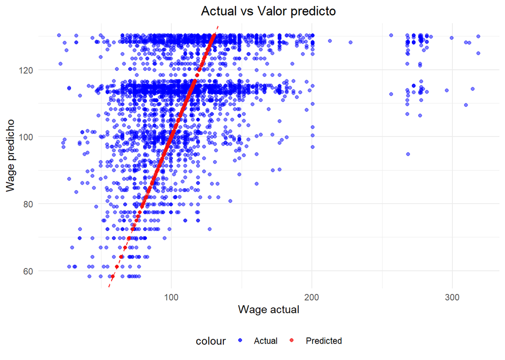

```r
Wage_regression$predicted_wage <- predict(model_maritl_fs, type = "response")

# Assuming Wage_regression already contains the actual 'wage' and predicted 'predicted_wage'
Wage_regression$actual_wage <- Wage_regression$wage  # Make sure the actual wage is in the data frame

ggplot(Wage_regression, aes(x = wage, y = predicted_wage)) +
  geom_point(aes(color = "Actual"), alpha = 0.5) +
  geom_point(aes(x = predicted_wage, y = predicted_wage, color = "Predicted"), alpha = 0.5) +
  geom_abline(intercept = 0, slope = 1, linetype = "dashed", color = "red") +
  scale_color_manual(values = c("Actual" = "blue", "Predicted" = "#f31111")) +
  labs(title = "Actual vs Valor predicto",
       x = "Wage actual",
       y = "Wage predicho") +
  theme_minimal() +
  theme(legend.position = "bottom",
        plot.title = element_text(hjust = 0.5))  # Center the plot title
```

Observamos que a medida que el salario aumenta, los errores en los valores predichos también aumentan. Los errores más significativos se observan especialmente en salarios superiores a 110. Sin embargo, nuestro modelo no es muy preciso y presenta una notable heteroscedasticidad.

```r
# Predecir el salario usando el modelo para todas las observaciones
Wage_regression$predicted_wage <- predict(model_maritl_fs, type = "response")

# Agregar para ver el salario promedio predicho para cada combinación de jobclass y maritl
salario_promedio_predicho_por_jobclass_maritl <- Wage_regression %>%
  group_by(jobclass, maritl) %>%
  summarise(SalarioPromedioPredicho = mean(predicted_wage))
# Imprimir el salario promedio predicho para cada combinación de jobclass y maritl
print(salario_promedio_predicho_por_jobclass_maritl)
```

```
## # A tibble: 10 × 3
## # Groups:   jobclass [2]
##    jobclass       maritl           SalarioPromedioPredicho
##    <fct>          <fct>                              <dbl>
##  1 1. Industrial  1. Never Married                    84.4
##  2 1. Industrial  2. Married                         111.
##  3 1. Industrial  3. Widowed                          99.3
##  4 1. Industrial  4. Divorced                         96.7
##  5 1. Industrial  5. Separated                        95.0
##  6 2. Information 1. Never Married                   104.
##  7 2. Information 2. Married                         126.
##  8 2. Information 3. Widowed                         110.
##  9 2. Information 4. Divorced                        112.
## 10 2. Information 5. Separated                       113.
```

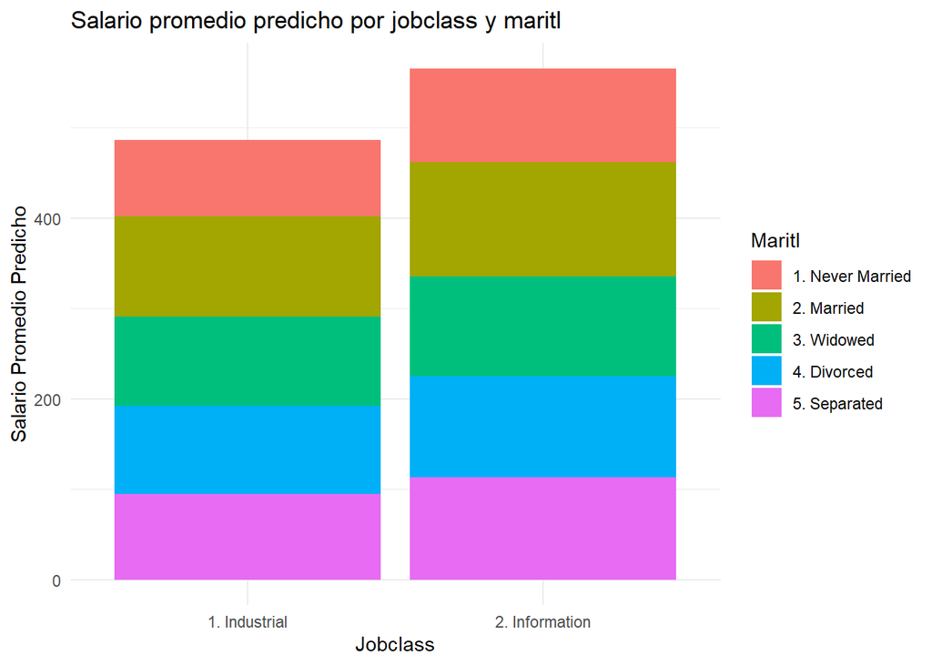

```r
#Graficar
ggplot(salario_promedio_predicho_por_jobclass_maritl, aes(x = jobclass, y = SalarioPromedioPredicho, fill = maritl)) +
  geom_bar(stat = "identity") +
  labs(title = "Salario promedio predicho por jobclass y maritl",
       x = "Jobclass",
       y = "Salario Promedio Predicho",
       fill = "Maritl") +
  theme_minimal()
```

Estamos evaluando el desempeño de nuestro modelo en la predicción de valores. Aquí, estamos calculando las medias agrupadas por las variables jobclass y martil. Observamos que las personas que trabajan en la categoría de “Información” tienen salarios ligeramente por encima del promedio en comparación con otras industrias. También notamos que este patrón se repite en cada categoría, donde el salario medio aumenta. Además, observamos que el estado marital “casado” tiene un impacto significativo en los salarios, como ya habíamos visto anteriormente en las gráficas de violín y en la regresión lineal.

## Punto 2

```r
# Cargar librerías
library(GGally)
```

[output not shown]

[output cut: 9 more lines]

[output not shown]

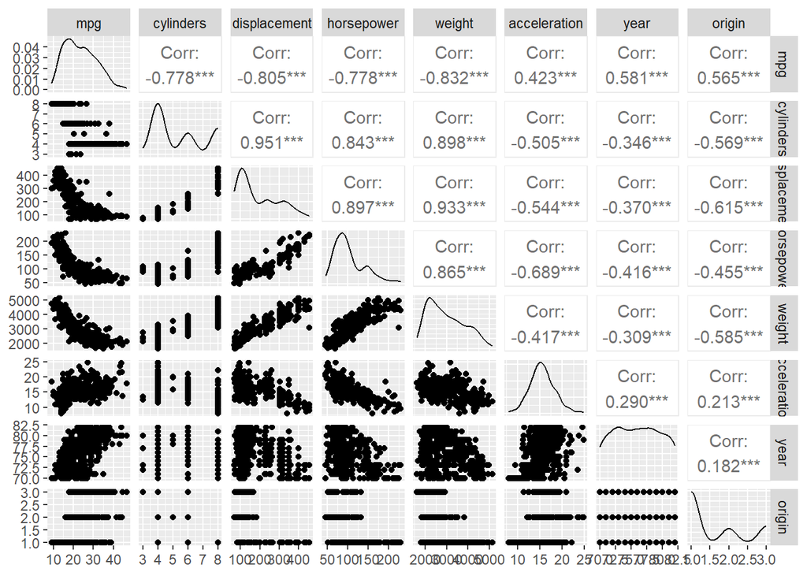

```r
# Cargar el conjunto de datos
load("auto.Rdata")


# Crear la matriz de gráficos de dispersión
ggpairs(Auto[, 1:8])  # Seleccionar solo las primeras 8 columnas ya que 'name' es categórica y no sería útil en una matriz de gráficos de dispersión
```

Por otro lado, se observan correlaciones negativas marcada entre ‘mpg’ y ‘cylinders’ (cilindros), ‘displacement’ (desplazamiento) y ‘horsepower’ (potencia). Esta relación indica que los vehículos con más cilindros, mayor desplazamiento y mayor potencia tienden a tener un menor rendimiento de combustible. Esta asociación es coherente con la idea de que los motores más grandes y potentes tienden a consumir más combustible.

```r
# Ajustar el modelo de regresión lineal múltiple
modelo <- lm(mpg ~ cylinders + displacement + horsepower + weight + acceleration + year + origin, data = Auto)

# Mostrar el resumen del modelo
summary(modelo)
```

```
##
## Call:
## lm(formula = mpg ~ cylinders + displacement + horsepower + weight +
##     acceleration + year + origin, data = Auto)
##
## Residuals:
##     Min      1Q  Median      3Q     Max
## -9.5903 -2.1565 -0.1169  1.8690 13.0604
##
## Coefficients:
##                Estimate Std. Error t value Pr(>|t|)
## (Intercept)  -17.218435   4.644294  -3.707  0.00024 ***
## cylinders     -0.493376   0.323282  -1.526  0.12780
## displacement   0.019896   0.007515   2.647  0.00844 **
## horsepower    -0.016951   0.013787  -1.230  0.21963
## weight        -0.006474   0.000652  -9.929  < 2e-16 ***
## acceleration   0.080576   0.098845   0.815  0.41548
## year           0.750773   0.050973  14.729  < 2e-16 ***
## origin         1.426141   0.278136   5.127 4.67e-07 ***
## ---
## Signif. codes:  0 '***' 0.001 '**' 0.01 '*' 0.05 '.' 0.1 ' ' 1
##
## Residual standard error: 3.328 on 384 degrees of freedom
## Multiple R-squared:  0.8215, Adjusted R-squared:  0.8182
## F-statistic: 252.4 on 7 and 384 DF,  p-value: < 2.2e-16
```

Observamos que los coeficientes de la intercepción, weight, year y origin, y en menor medida displacement, son significativos en nuestro modelo. Los residuos parecen tener valores mínimos y máximos altos, sin embargo, la media de los residuos está cercana a 0. El coeficiente de determinación (R cuadrado) es 0.82, lo que indica que el modelo explica una gran parte de la varianza en nuestros datos(82%). Además, el valor p asociado al modelo es muy pequeño, lo que sugiere que al menos uno de los predictores está asociado con ‘mpg’, lo que hace que nuestro modelo sea estadísticamente significativo.

¿Hay alguna relación entre los predictores y la respuesta? ¿Cuáles predictores tienen una relación estadísticamente significativa

Si, vemos que las variables más significativas son weigth,year y origin y en menor medida displacement. Tienen una relación linea con la variable *mpg*, ahora tambien vemos que el F stadistico es 252 y su valor p es muy pequeño. Lo que nos indica que estadisticamente si hay una relación con almenos una variable predictiva.

¿Qué sugiere el coeficiente de la variable year?

El coeficiente de la variable ‘year’ sugiere una relación lineal entre ‘mpg’ y el año de fabricación del carro. En promedio, hay un aumento en ‘mpg’ a medida que el año aumenta. Esto sugiere que los vehículos más recientes tienden a tener un mayor rendimiento de combustible en comparación con vehículos más antiguos.

### Diagnostico

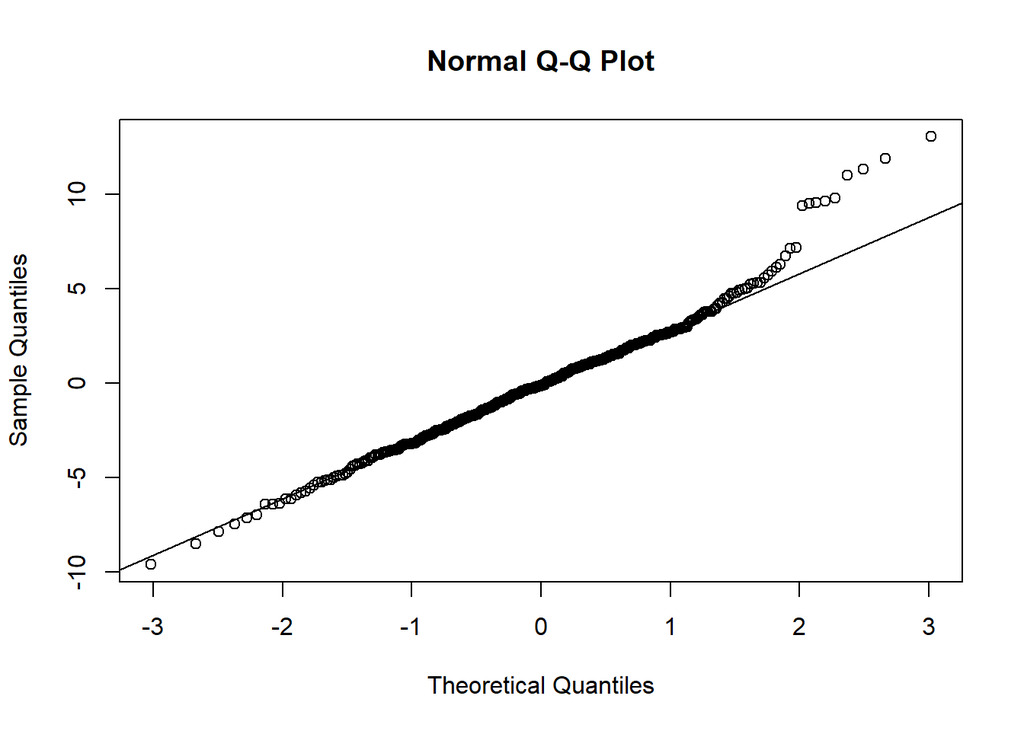

```r
# QQ plot de los residuos
qqnorm(modelo$residuals)
qqline(modelo$residuals)
```

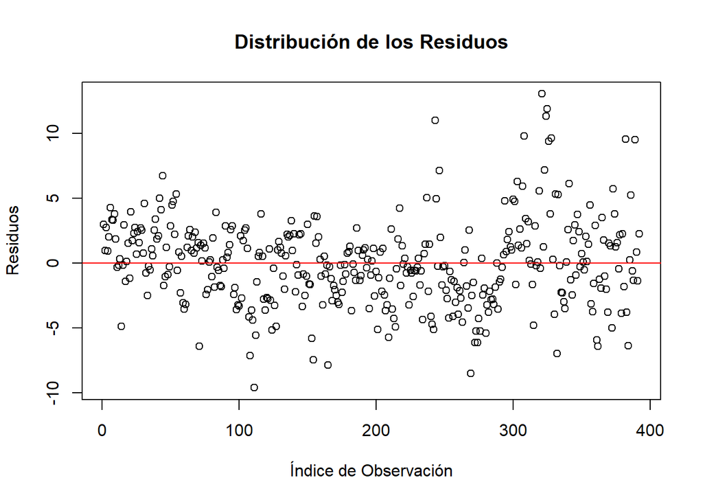

```r
# Gráfica de distribución de los residuos con línea en y = 0
plot(modelo$residuals, ylab = "Residuos", xlab = "Índice de Observación",
     main = "Distribución de los Residuos")
abline(h = 0, col = "red")  # Línea en y = 0
```

### Regresión Lineal con interacciones.

```r
# Realizar una nueva regresión incluyendo interacciones
modelo_interaccion <- lm(mpg ~ cylinders + displacement + horsepower + weight + acceleration + year + origin +
                           acceleration:year + origin:year + cylinders:displacement, data = Auto)

summary(modelo_interaccion)
```

```
##
## Call:
## lm(formula = mpg ~ cylinders + displacement + horsepower + weight +
##     acceleration + year + origin + acceleration:year + origin:year +
##     cylinders:displacement, data = Auto)
##
## Residuals:
##      Min       1Q   Median       3Q      Max
## -11.0176  -1.7176   0.0432   1.4632  12.3945
##
## Coefficients:
##                          Estimate Std. Error t value Pr(>|t|)
## (Intercept)             1.015e+02  1.979e+01   5.128 4.68e-07 ***
## cylinders              -2.347e+00  4.045e-01  -5.804 1.36e-08 ***
## displacement           -8.217e-02  1.369e-02  -6.000 4.59e-09 ***
## horsepower             -4.995e-02  1.293e-02  -3.864 0.000131 ***
## weight                 -4.785e-03  6.064e-04  -7.890 3.24e-14 ***
## acceleration           -5.153e+00  1.228e+00  -4.196 3.38e-05 ***
## year                   -6.104e-01  2.586e-01  -2.360 0.018767 *
## origin                 -1.299e+01  4.307e+00  -3.015 0.002742 **
## acceleration:year       6.801e-02  1.595e-02   4.265 2.52e-05 ***
## year:origin             1.752e-01  5.525e-02   3.171 0.001644 **
## cylinders:displacement  1.263e-02  1.678e-03   7.523 3.89e-13 ***
## ---
## Signif. codes:  0 '***' 0.001 '**' 0.01 '*' 0.05 '.' 0.1 ' ' 1
##
## Residual standard error: 2.97 on 381 degrees of freedom
## Multiple R-squared:  0.8589, Adjusted R-squared:  0.8552
## F-statistic:   232 on 10 and 381 DF,  p-value: < 2.2e-16
```

Añadiendo las interacciones acceleration:year, year:origin, y cylinders:displacement, vemos que tenemos un $R^{2}$ de $0.86$ y un error residual estandar de 2.97 que es menor al que teniamos, tenemos un modelo mejor, sin embargo estamos perdiendo interpretabilidad al añadir las interacciones.

¿Recomendaría usar alguna transformación como $Log(X)$ o $X^{2}$

Como vimos anteriormente, tenemos un posible problema de heterosedasticidad. Luego una transformación Logaritmica nos puede ayudar.

```r
# Aplicar la transformación logarítmica a la variable de respuesta
Auto$log_mpg <- log(Auto$mpg)

# Realizar una nueva regresión con la variable de respuesta transformada
modelo_interaccion_log <- lm(log_mpg ~ cylinders + displacement + horsepower + weight + acceleration + year + origin +
                           acceleration:year + origin:year + cylinders:displacement, data = Auto)

# Mostrar el resumen del nuevo modelo
summary(modelo_interaccion_log)
```

```
##
## Call:
## lm(formula = log_mpg ~ cylinders + displacement + horsepower +
##     weight + acceleration + year + origin + acceleration:year +
##     origin:year + cylinders:displacement, data = Auto)
##
## Residuals:
##      Min       1Q   Median       3Q      Max
## -0.46580 -0.06023  0.00337  0.06569  0.39150
##
## Coefficients:
##                          Estimate Std. Error t value Pr(>|t|)
## (Intercept)             5.331e+00  7.495e-01   7.113 5.67e-12 ***
## cylinders              -6.953e-02  1.531e-02  -4.540 7.54e-06 ***
## displacement           -1.856e-03  5.185e-04  -3.580 0.000389 ***
## horsepower             -2.410e-03  4.895e-04  -4.922 1.27e-06 ***
## weight                 -2.106e-04  2.296e-05  -9.171  < 2e-16 ***
## acceleration           -1.983e-01  4.650e-02  -4.266 2.52e-05 ***
## year                   -1.267e-02  9.791e-03  -1.294 0.196490
## origin                 -6.882e-02  1.631e-01  -0.422 0.673247
## acceleration:year       2.560e-03  6.038e-04   4.239 2.81e-05 ***
## year:origin             1.146e-03  2.092e-03   0.548 0.584157
## cylinders:displacement  3.028e-04  6.354e-05   4.766 2.68e-06 ***
## ---
## Signif. codes:  0 '***' 0.001 '**' 0.01 '*' 0.05 '.' 0.1 ' ' 1
##
## Residual standard error: 0.1124 on 381 degrees of freedom
## Multiple R-squared:  0.8935, Adjusted R-squared:  0.8907
## F-statistic: 319.5 on 10 and 381 DF,  p-value: < 2.2e-16
```

### Transformación $Log(X)$

Observamos que al realizar la transformación logarítmica, nuestro modelo mejora considerablemente. El coeficiente de $R^{2}$ alcanza un valor de 0.893 y el error estándar se reduce a 0.11. Sin embargo, vamos a ver cómo cambian los residuos después de esta transformación.

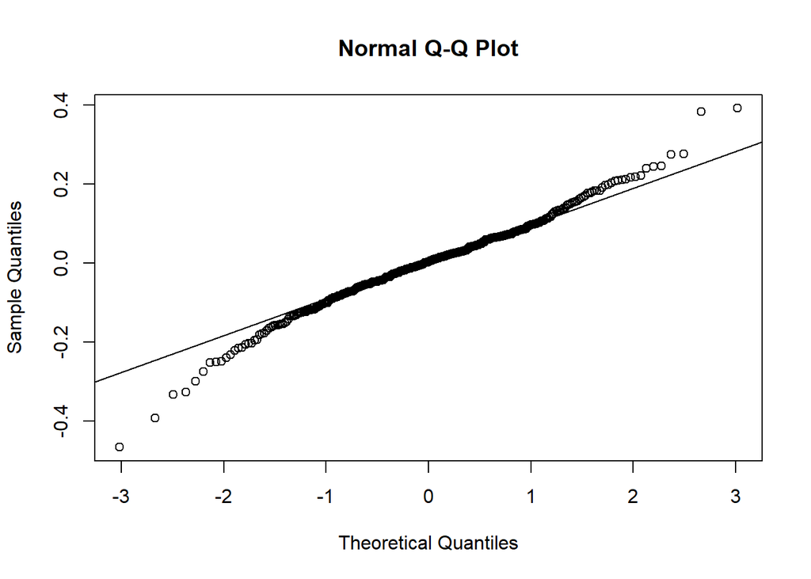

```r
# Obtener los residuos del modelo
residuos_modelo <- residuals(modelo_interaccion_log)

# QQ plot de los residuos
qqnorm(residuos_modelo)
qqline(residuos_modelo)
```

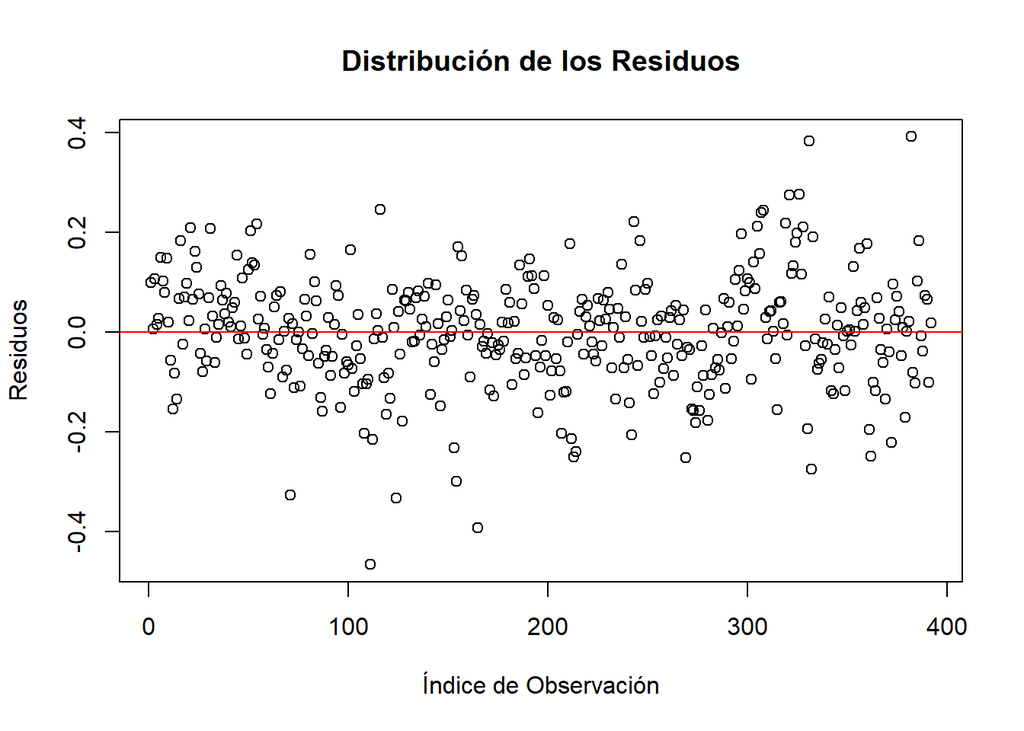

```r
# Gráfica de distribución de los residuos con línea en y = 0
plot(residuos_modelo, ylab = "Residuos", xlab = "Índice de Observación",
     main = "Distribución de los Residuos")
abline(h = 0, col = "red")  # Línea en y = 0
```